[O’Hara on GitHub](https://github.com/oharac)

# Matrix testing

Compiled on Thu Sep 5 07:47:07 2019 by ohara

```r
library(raster)
source('https://raw.githubusercontent.com/oharac/src/master/R/common.R')

source(here::here('common_fxns.R'))

dir_bd_anx  <- '~/git-annex/bd_chi' ### this is on git-annex in home/ohara
dir_spp_anx <- '~/git-annex/spp_risk_dists'
dir_cons <- 'layers/cons_priorities'
dir_str  <- 'layers/stressors_10km'
```

# 1 Summary

Trying out matrix techniques for this analysis.

# 2 Methods

Bring in info on species presence (for a small handful of species), stressor presence (for a handful of stressors), convert these to matrices; create a stressor weight matrix.

Let $\mathbf X$ be an $n \times k$ matrix that maps species to cells, where $n$ is the number of species and $k$ is the number of cells. Let $\mathbf Y$ be an $j \times k$ matrix that maps stressors to cells, where $j$ is the number of stressors. Let $\mathbf W$ be an $n \times i$ matrix that provides stressor weights for each species.

### 2.0.1 Species presence matrix

This is a little trickier because the species maps are saved as `.csvs` of `cell_id` and `presence`, rather than rasters including all cell values. So: create an empty matrix with $n$ rows and $k$ columns, filled with zeroes, and for each species, fill that row in with 1s for each column associated with a cell ID.

```
##    user  system elapsed
##   2.556   2.364   4.922
```

```
## [1]     100 6160050
```

#### 2.0.1.1 Examine object size

Considering we want to do this for 7000+ maps, we need to be cognizant of the object size. For the entire matrix (all cells), object size for 100 spp is ~5GB; filtered to ocean cells only, object size drops to ~3GB. This, combined with memory required for a stressor matrix and processing, suggests we need to do this in chunks - taxonomic groups seems to make the most sense.

```
## 4928047048 bytes
```

```
## 2787854248 bytes
```

```
## [1]     100 6160050
```

```
## [1]     100 3484809
```

### 2.0.2 Setting up stressor matrix

Set up a stressor matrix and stressor weight matrix.

```
##  [1] "art_fish_2014_rescaled_mol10km.tif"
##  [2] "benthic_str_2016_rescaled_mol10km.tif"
##  [3] "dem_dest_2014_rescaled_mol10km.tif"
##  [4] "dem_nondest_hb_2014_rescaled_mol10km.tif"
##  [5] "dem_nondest_lb_2014_rescaled_mol10km.tif"
##  [6] "direct_human_2016_rescaled_mol10km.tif"
##  [7] "light_2013_rescaled_mol10km.tif"
##  [8] "nutrient_2013_rescaled_mol10km.tif"
##  [9] "oa_2017_rescaled_mol10km.tif"
## [10] "organic_2013_rescaled_mol10km.tif"
## [11] "pel_hb_2014_rescaled_mol10km.tif"
## [12] "pel_lb_2014_rescaled_mol10km.tif"
## [13] "shipping_2016_rescaled_mol10km.tif"
## [14] "slr_2016_rescaled_mol10km.tif"
## [15] "sst_2017_rescaled_mol10km.tif"
## [16] "uv_2016_rescaled_mol10km.tif"
```

```
##    user  system elapsed
##  14.168   2.868  17.038
```

```
## [1]      16 6160050
```

Compare object sizes for full stressor matrix (all cells) and ocean cells only.

```
## 788486616 bytes
```

```
## 446055768 bytes
```

```
## [1]      16 6160050
```

```
## [1]      16 3484809
```

### 2.0.3 Set up sample vectors

To allow for single-species and single-stressor examples, let $\mathbf x$ be a $n \times 1$ vector mapping the presence of a single species, while $\mathbf y$ is a $k \times 1$ vector mapping the intensity of a single stressor, and $\mathbf w$ is an $i \times 1$ vector of stressor weights on a single species.

Let $\mathbf m$ can be a 1 $\times k$ vector of 1s and 0s denoting ocean status of each of $k$ cells (alternately, could be area?). For $\mathbf x$ (and $\mathbf w$), use species 4 in this case, because a larger range; let’s also use stressor 4 for $\mathbf y$.

## 2.1 Range area

Total area (by cells, easily converted to km<sup>2</sup>) of a species range (for species $spp$) is simply the sum of the presences in $\mathbf x$, noted by scalar $a_{spp}$:
$$a_{spp} = \mathbf x_{spp}^T \mathbf m$$
and area for all species is a $n \times 1$ vector:
$$\mathbf a = \mathbf X^T \mathbf m$$

```
##       [,1]
## [1,] 70122
```

```
##              [,1]
## 44617        1884
## 10939        1782
## 133344       2203
## 133354      70122
## 22693289     6158
## 179092       2322
## 195455      19302
## 133229        232
## 48342414        5
## 173348      14367
## 165712      59357
## 70686656    12089
## 116863801     295
## 133687       7020
```

[output cut: 86 more lines]

## 2.2 Exposure to stressors

Total (unweighted) exposure $z$ of a given species $spp$ to given stressor $str$ is scalar:
$$z_{spp,str} = \mathbf x_{spp} \mathbf y_{str}^T$$
while total exposure of all species for all stressors is an $n \times i$ matrix:
$$\mathbf Z = \mathbf X \mathbf Y^T$$

```
##          [,1]
## [1,] 1177.702
```

```
##                   [,1]        [,2]         [,3]         [,4]         [,5]
## 44617     4.671426e+01 0.000000000 1.425073e+01 8.679388e-02 4.278959e-02
## 10939     9.471265e+00 0.008264462 5.128106e+00 3.275018e+00 1.136619e-01
## 133344    1.327368e+02 0.100127928 7.210175e+01 3.285168e+01 4.779170e+01
## 133354    2.992124e+03 1.708532571 1.914056e+03 1.177702e+03 5.602247e+02
## 22693289  2.364624e+02 0.099760538 1.458249e+02 1.330074e+02 7.604001e+01
## 179092    8.111274e-01 0.000000000 2.771104e+00 6.416155e+00 1.123721e+01
## 195455    1.304068e+02 0.074380162 6.512537e+01 4.637178e+01 4.122842e+00
## 133229    3.908515e-01 0.000000000 2.184299e-01 7.341701e-02 3.688750e-02
## 48342414  1.612381e-01 0.000000000 8.031700e-02 4.954731e-04 9.607637e-03
## 173348    1.720649e+03 0.593154965 9.965791e+02 9.839691e+02 3.714463e+02
## 165712    2.966027e+03 1.600091050 1.763280e+03 1.123245e+03 4.591745e+02
## 70686656  2.250697e+01 0.090909087 7.405851e+01 2.010335e+01 2.496168e+01
## 116863801 0.000000e+00 0.000000000 2.435655e-05 7.588275e-05 0.000000e+00
## 133687    2.365280e+02 0.100127928 1.274102e+02 3.353569e+01 4.799645e+01
```

[output cut: 389 more lines]

### 2.2.1 Area of exposure

Area of a species’ range exposed to a stressor would be found by the overlapping area of a normalized stressor matrix, i.e. stressor presence = 1 for any cell with stressor value > 0. Divide that by the total range, and get the proportion of range for that species exposed to some level of that stressor.

```
##             [,1] [,2]   [,3]   [,4]   [,5]  [,6]  [,7]  [,8]    [,9] [,10]
## 44617       1804    0   1878   1482   1495   537    68  1409    1884  1225
## 10939       1478    1   1760   1760   1135   175   138   567    1782   448
## 133344      2193    9   2201   2182   2115   662   278  1147    2203   787
## 133354     65234  178  69852  65263  60971 14223  7051 26075   70122 21809
## 22693289    5118    4   6092   5914   5508  6051  1321  5832    6158  5714
## 179092      2311    0   2311   2317   2317   252    15   776    2322   579
## 195455     19226    9  19293  19228  17919  1932   322  4809   19302  3728
## 133229       193    0    193    182    198    79    55   109     232   108
## 48342414       5    0      5      5      5     2     0     0       5     0
## 173348     13366   54  14068  13320  13281  2955  4429  7128   14367  6149
## 165712     54320  165  58685  53917  50150 13710  6808 23411   59357 19683
## 70686656   10298   11  10961  11042  10691  1356   353  4941   12089  3930
## 116863801      0    0    107    115      0     0     0     0     295     0
## 133687      6736    9   6971   6381   6116  1811   492  3478    7020  2773
```

[output cut: 187 more lines]

```
##            [,1]  [,2]  [,3]  [,4]  [,5]  [,6]  [,7]  [,8]  [,9] [,10]
## 44617     0.958 0.000 0.997 0.787 0.794 0.285 0.036 0.748 1.000 0.650
## 10939     0.829 0.001 0.988 0.988 0.637 0.098 0.077 0.318 1.000 0.251
## 133344    0.995 0.004 0.999 0.990 0.960 0.300 0.126 0.521 1.000 0.357
## 133354    0.930 0.003 0.996 0.931 0.869 0.203 0.101 0.372 1.000 0.311
## 22693289  0.831 0.001 0.989 0.960 0.894 0.983 0.215 0.947 1.000 0.928
## 179092    0.995 0.000 0.995 0.998 0.998 0.109 0.006 0.334 1.000 0.249
## 195455    0.996 0.000 1.000 0.996 0.928 0.100 0.017 0.249 1.000 0.193
## 133229    0.832 0.000 0.832 0.784 0.853 0.341 0.237 0.470 1.000 0.466
## 48342414  1.000 0.000 1.000 1.000 1.000 0.400 0.000 0.000 1.000 0.000
## 173348    0.930 0.004 0.979 0.927 0.924 0.206 0.308 0.496 1.000 0.428
## 165712    0.915 0.003 0.989 0.908 0.845 0.231 0.115 0.394 1.000 0.332
## 70686656  0.852 0.001 0.907 0.913 0.884 0.112 0.029 0.409 1.000 0.325
## 116863801 0.000 0.000 0.363 0.390 0.000 0.000 0.000 0.000 1.000 0.000
## 133687    0.960 0.001 0.993 0.909 0.871 0.258 0.070 0.495 1.000 0.395
```

[output cut: 187 more lines]

## 2.3 Cumulative impact to species

### 2.3.1 Cumulative weighted stressors

The cumulative weighted stressors $\mathbf q_{spp}$ upon a species for a vector of cells should be a $k \times 1$ vector that maps cumulative impact on a species, regardless of species presence.
$$\mathbf q_{spp} = \mathbf w_{spp} \mathbf Y$$
and for all species, an $n \times k$ matrix of cumulative weighted stressor for all species:
$$\mathbf Q = \mathbf W^T \mathbf Y$$

The cumulative impacts are then the species presence times the species cumulative weighted stressors, i.e. for a single species:
$$chi = \mathbf x \mathbf q^T$$
and across all species, the diagonal of the multiplied matrices:
$$CHI = \text{diag}(\mathbf X\mathbf Q^T)$$

```
##   [1] 2.437211e+03 3.414742e+03 2.880232e+03 1.053403e+05 8.410434e+03
##   [6] 9.954129e+02 2.046330e+04 4.039575e+02 1.138480e+00 2.355933e+04
##  [11] 3.651186e+04 9.669613e+03 2.099793e+02 5.749148e+03 1.207571e+05
##  [16] 5.464390e+01 5.673079e+02 8.272095e+03 4.954837e+00 3.190242e+03
##  [21] 1.251754e+03 3.573142e+04 6.270138e+02 8.526971e+02 8.068154e+03
##  [26] 1.892799e+04 3.143830e+04 1.029435e+03 1.326249e+04 1.090912e+04
##  [31] 6.398662e+04 4.235059e+02 2.570973e+03 2.957594e+03 6.606966e+02
##  [36] 3.240126e+04 4.319376e+03 1.171006e+03 7.400219e+02 2.987349e+02
##  [41] 7.446719e+04 1.248262e+03 7.856286e+01 2.713267e+04 6.490060e+02
##  [46] 6.984923e+00 3.805326e+03 3.309622e+02 4.835552e+03 1.701922e+06
##  [51] 1.664796e+02 2.533603e+02 7.031764e+03 3.295358e+04 5.961906e+03
##  [56] 2.392037e+01 4.635416e+04 6.224057e+04 4.949472e+03 5.652204e+03
##  [61] 1.038389e+04 3.272763e+04 4.049945e+03 2.207129e+02 4.220667e+03
##  [66] 2.436389e+04 7.197998e+04 6.571545e+03 7.636546e+02 1.178085e+05
##  [71] 5.807305e+00 7.888010e+04 2.722154e+06 5.009576e+03 6.707371e+03
##  [76] 5.596891e+03 4.230495e+03 2.866913e+03 1.214163e+01 3.090746e+04
##  [81] 1.482288e+04 1.629038e+03 1.089748e+04 4.662954e+04 1.350232e+04
##  [86] 3.110437e+01 1.263214e+02 5.949751e+02 3.238615e+02 8.055402e+03
##  [91] 1.318117e+03 1.587095e+04 6.978656e+01 2.098856e+04 2.818629e+02
##  [96] 4.655296e+03 1.687572e+02 1.959373e+04 1.342893e+04 1.033398e+05
```

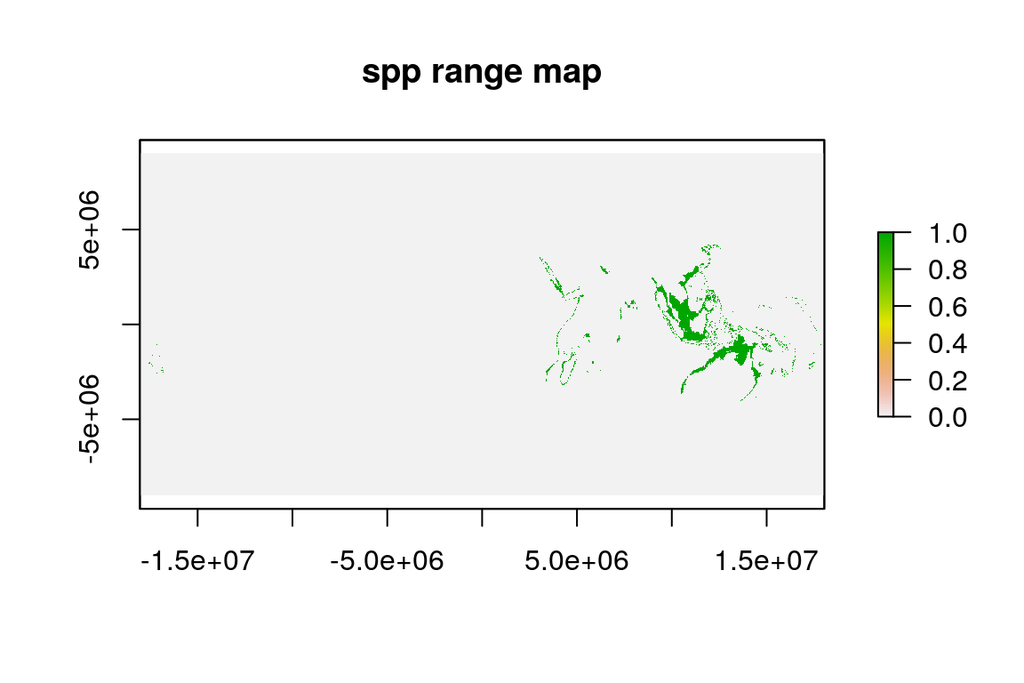

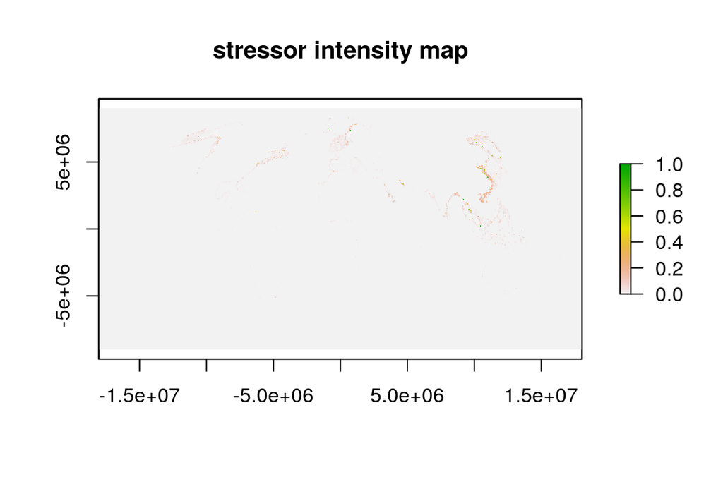

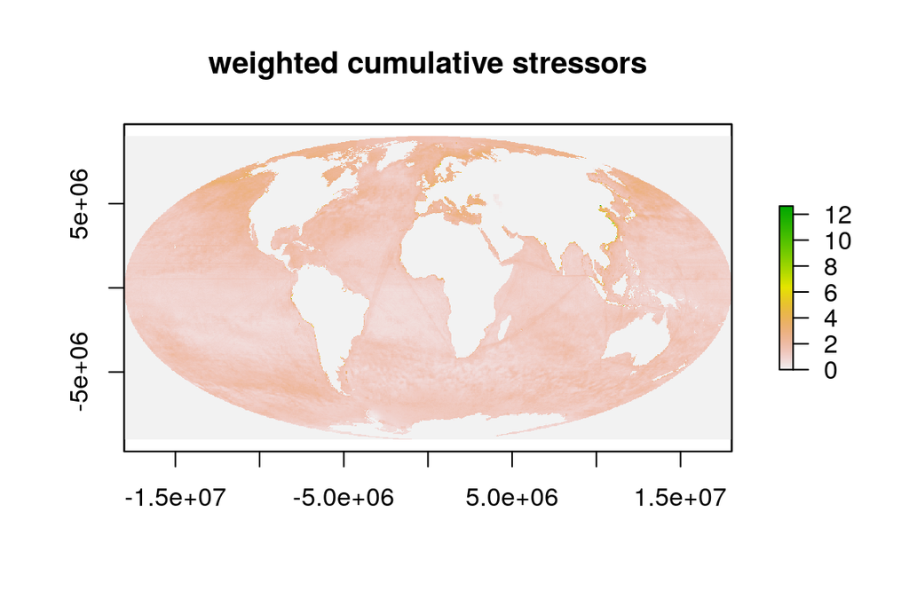

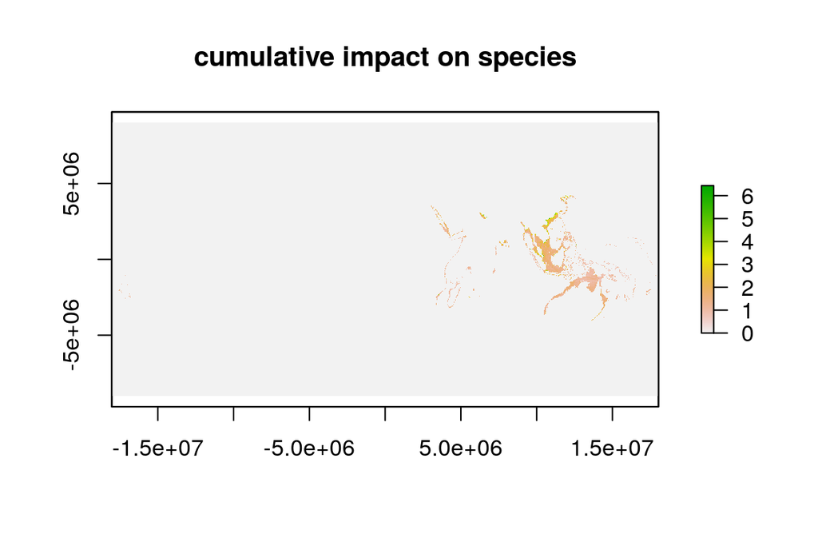

```
## [1] 105340.3
```